# Regression model VIII : Shrinkage

Read the chapter 11

Sometimes it can seem like you have too many predictors. If you use them all in your regression model, problems can arise. Explanation can be difficult due to collinearity as we saw before. Prediction performance can also be degraded by using too many predictors. But more predictors should mean more information. That should be helpful.

# 1 Ridge regression

Ridge regression makes the assumption that the regression coefficients (after normalization) should not be very large. Ridge regression is particularly effective when the model matrix is collinear and the usual least squares estimates of $\beta$ appear to be unstable.

Suppose that the predictors have been centered by their means and scaled by their standard deviations and that the response has been centered. The ridge regression estimate chooses the $\beta$ that minimizes:

$$(y-X\beta)^\top(y-X\beta) + \lambda\sum_{j=1}^p \beta_j^2$$

Ridge regression is an example of a penalized regression because of the presence of this term. The ridge regression estimates are given by:

$$\hat\beta = (X^\top X + \lambda I)^{-1} X^\top y$$
The $\lambda I$ introduces a “ridge” down the $X^\top X$ matrix, hence the name of the method. An equivalent expression of the problem is that we choose b to minimize:

$$(y-X\beta)^\top(y-X\beta) \mbox{ subject to } \sum_{j=1}^p \beta_j^2 \leq t^2$$

The use of ridge regression can also be justified from a Bayesian perspective where a prior distribution on the parameters puts more weight on smaller values.

```r
library(faraway)
data(meatspec, package="faraway")
trainmeat <- meatspec[1:172,]     # decomposition of data
testmeat <- meatspec[173:215,]
rmse <- function(x,y) sqrt(mean((x-y)^2))  # root MSE
require(MASS)
```

```r
rgmod <- lm.ridge(fat ~ ., trainmeat, lambda = seq(0, 5e-8, len=21))
matplot(rgmod$lambda, coef(rgmod), type="l", xlab=expression(lambda),ylab=expression(hat(beta)),col=1)
which.min(rgmod$GCV)    # estimated lambda minimizing GCV criterion
```

```
## 1.75e-08
##        8
```

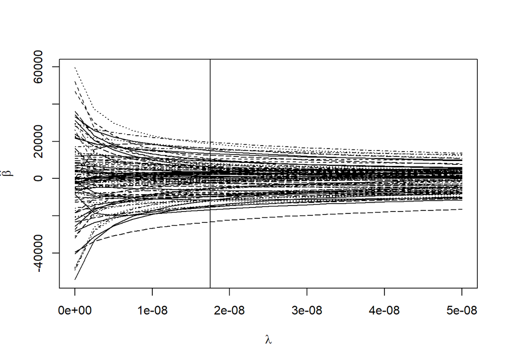

```r
abline(v=1.75e-08)
```

```r
ypred <- cbind(1,as.matrix(trainmeat[,-101])) %*% coef(rgmod)[8,]   # predicted value for training data
rmse(ypred, trainmeat$fat)
```

```
## [1] 0.8024395
```

```r
ypred <- cbind(1,as.matrix(testmeat[,-101])) %*% coef(rgmod)[8,]    # predicted value for test data
rmse(ypred, testmeat$fat)
```

```
## [1] 4.101066
```

```r
rmse(ypred[-13], testmeat$fat[-13])    # after removing a bad fit
```

```
## [1] 1.979462
```

$\lambda = 0$ corresponds to least squares while we find that as $\lambda \rightarrow \infty$ : $\hat\beta \rightarrow 0$.

```r
rgmod <- lm.ridge(fat ~ ., trainmeat, lambda = 0)  # ridge with lambda=0
coef(rgmod)
```

```
##                          V1            V2            V3            V4
##      6.323831  12134.077497 -12585.856915  -5107.556442  23880.493009
##            V5            V6            V7            V8            V9
## -40509.554868  28469.415827 -20901.082407   8369.465253  -1539.328060
##           V10           V11           V12           V13           V14
##   4706.267463   7012.943385  14891.443965 -30963.901605  34338.611931
##           V15           V16           V17           V18           V19
## -22235.236568  -7466.796789   6716.653150  -2033.070921   8541.212271
##           V20           V21           V22           V23           V24
##  -1667.206995 -31972.494074  59526.388509 -49241.388436  16184.597496
##           V25           V26           V27           V28           V29
##  12077.951472 -12632.329980  -6298.837028  29625.988194 -39374.835056
##           V30           V31           V32           V33           V34
##  31251.427084 -27238.188664  23009.543359  -4584.373317  -5437.942601
##           V35           V36           V37           V38           V39
##  -6128.931232   5599.605435  -5569.159897     97.450599  36021.406546
##           V40           V41           V42           V43           V44
## -54273.399795  52084.876500 -48458.088605  29334.488417 -18282.834003
##           V45           V46           V47           V48           V49
##  22110.933657 -11735.692368   -514.520845   2551.479919   3707.638966
##           V50           V51           V52           V53           V54
## -25762.702534  46844.467617 -47783.626000  26233.603615     87.825462
##           V55           V56           V57           V58           V59
##  -8475.119092   3488.507231  -1520.733291   2275.175219  -5415.427460
##           V60           V61           V62           V63           V64
##   7152.014744  -4494.234084   3662.044754  13993.987332 -23252.132570
##           V65           V66           V67           V68           V69
##   4373.730864   4580.912577   -837.675978  -7074.425460   9506.570745
##           V70           V71           V72           V73           V74
##  -2765.099495  -1125.135458  -7295.096410  17059.811323  -9889.553256
##           V75           V76           V77           V78           V79
##   -325.614605    782.219081   8058.934802 -15869.978269  21768.619362
##           V80           V81           V82           V83           V84
## -28338.145283   8523.316793  22319.450598 -17244.721848 -18325.836092
##           V85           V86           V87           V88           V89
##  33345.456759  -7955.157324  -7837.965948  -1815.551726    631.594941
##           V90           V91           V92           V93           V94
##  -2701.954593   4375.678229  12925.187938  -7441.234523  -2464.531623
##           V95           V96           V97           V98           V99
##  -2090.634886  10912.351738 -20331.405345   3948.442903   6358.929646
##          V100
##   -263.364566
```

```r
lmod <- lm(fat ~ ., trainmeat)  # linear model
coef(lmod)
```

```
##   (Intercept)            V1            V2            V3            V4
##      6.323831  12134.077498 -12585.856917  -5107.556440  23880.493017
##            V5            V6            V7            V8            V9
## -40509.554889  28469.415848 -20901.082421   8369.465257  -1539.328060
##           V10           V11           V12           V13           V14
##   4706.267470   7012.943371  14891.443981 -30963.901624  34338.611942
##           V15           V16           V17           V18           V19
## -22235.236570  -7466.796788   6716.653149  -2033.070917   8541.212270
##           V20           V21           V22           V23           V24
##  -1667.206998 -31972.494070  59526.388500 -49241.388427  16184.597490
##           V25           V26           V27           V28           V29
##  12077.951474 -12632.329978  -6298.837024  29625.988183 -39374.835047
##           V30           V31           V32           V33           V34
##  31251.427080 -27238.188659  23009.543355  -4584.373315  -5437.942603
##           V35           V36           V37           V38           V39
##  -6128.931225   5599.605427  -5569.159894     97.450600  36021.406544
##           V40           V41           V42           V43           V44
## -54273.399793  52084.876498 -48458.088606  29334.488422 -18282.834004
##           V45           V46           V47           V48           V49
##  22110.933655 -11735.692369   -514.520842   2551.479922   3707.638957
##           V50           V51           V52           V53           V54
## -25762.702528  46844.467617 -47783.626003  26233.603618     87.825461
##           V55           V56           V57           V58           V59
##  -8475.119091   3488.507229  -1520.733288   2275.175219  -5415.427463
##           V60           V61           V62           V63           V64
##   7152.014747  -4494.234087   3662.044756  13993.987334 -23252.132573
##           V65           V66           V67           V68           V69
##   4373.730864   4580.912580   -837.675976  -7074.425469   9506.570756
##           V70           V71           V72           V73           V74
##  -2765.099505  -1125.135449  -7295.096419  17059.811330  -9889.553261
##           V75           V76           V77           V78           V79
##   -325.614601    782.219077   8058.934808 -15869.978272  21768.619363
##           V80           V81           V82           V83           V84
## -28338.145289   8523.316801  22319.450593 -17244.721842 -18325.836096
##           V85           V86           V87           V88           V89
##  33345.456755  -7955.157318  -7837.965944  -1815.551737    631.594946
##           V90           V91           V92           V93           V94
##  -2701.954586   4375.678217  12925.187941  -7441.234514  -2464.531631
##           V95           V96           V97           V98           V99
##  -2090.634888  10912.351746 -20331.405355   3948.442908   6358.929647
##          V100
##   -263.364567
```

```r
sum(coef(rgmod)^2)
```

```
## [1] 42829593396
```

```r
sum(coef(lmod)^2)
```

```
## [1] 42829593399
```

```r
rgmod <- lm.ridge(fat ~ ., trainmeat, lambda = 100000) # ridge with lambda>>0
coef(rgmod)
```

```
##                      V1          V2          V3          V4          V5
## 12.59716722  0.01812780  0.01797696  0.01783319  0.01769621  0.01756725
##          V6          V7          V8          V9         V10         V11
##  0.01744799  0.01734024  0.01724520  0.01716264  0.01709246  0.01703393
##         V12         V13         V14         V15         V16         V17
##  0.01698909  0.01696067  0.01695162  0.01696325  0.01699446  0.01704336
##         V18         V19         V20         V21         V22         V23
##  0.01711067  0.01719538  0.01729254  0.01739357  0.01748510  0.01755599
##         V24         V25         V26         V27         V28         V29
##  0.01760249  0.01762999  0.01765220  0.01769127  0.01776647  0.01788673
##         V30         V31         V32         V33         V34         V35
##  0.01805039  0.01824289  0.01844174  0.01862628  0.01878633  0.01892393
##         V36         V37         V38         V39         V40         V41
##  0.01904879  0.01916782  0.01927344  0.01934941  0.01937617  0.01933602
##         V42         V43         V44         V45         V46         V47
##  0.01921344  0.01899800  0.01868852  0.01829800  0.01785726  0.01740818
##         V48         V49         V50         V51         V52         V53
##  0.01699763  0.01664806  0.01636600  0.01614636  0.01597765  0.01584823
##         V54         V55         V56         V57         V58         V59
##  0.01574945  0.01567427  0.01561815  0.01557634  0.01554711  0.01552311
##         V60         V61         V62         V63         V64         V65
##  0.01550702  0.01549643  0.01549033  0.01549049  0.01549766  0.01551120
##         V66         V67         V68         V69         V70         V71
##  0.01553177  0.01555703  0.01559185  0.01563580  0.01569010  0.01575379
##         V72         V73         V74         V75         V76         V77
##  0.01582660  0.01590962  0.01600217  0.01610054  0.01620550  0.01631660
##         V78         V79         V80         V81         V82         V83
##  0.01643522  0.01655968  0.01669591  0.01684062  0.01698936  0.01713750
##         V84         V85         V86         V87         V88         V89
##  0.01728029  0.01741538  0.01753724  0.01764645  0.01774830  0.01784972
##         V90         V91         V92         V93         V94         V95
##  0.01795653  0.01807105  0.01819108  0.01831061  0.01842430  0.01852814
##         V96         V97         V98         V99        V100
##  0.01861997  0.01869586  0.01875208  0.01878820  0.01880752
```

```r
sum(coef(rgmod)[-1]^2)
```

```
## [1] 0.02991897
```

Ridge regression estimates of coefficients are biased. But, the resulting estimator gets more stable in the presence of multicollinearity. In that case, a large reduction in the variance may be obtained at the price of an increase in the bias.

# 2 LASSO (least absolute shrinkage and selection operator)

LASSO penalizes coefficient terms in the way of minimizing

$$(y-X\beta)^\top(y-X\beta) + \lambda\sum_{j=1}^p |\beta_j|$$

and this is equivalent to minimizing

$$(y-X\beta)^\top(y-X\beta) \mbox{ subject to } \sum_{j=1}^p |\beta_j| \leq t$$
There is no explicit solution to this problem as in the ridge regression case although it can be found quite efficiently in the context of a more general method called least angle regression.

The important difference between lasso and ridge regression is on how we penalize the coefficient terms. For the LASSO, we use a $L_1$ constraint and for the ridge, we use a $L_2$ constraint. This difference causes different forms of solutions. See the figure below

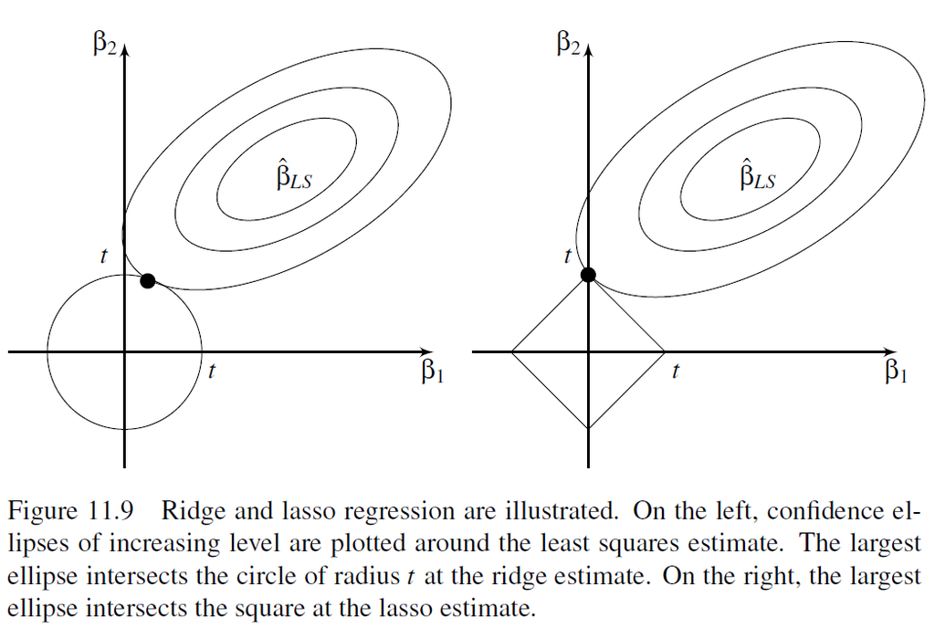

The LASSO solutions tend to be sparse. It means that some of estimated coefficients are exactly zero. Therefore, by using LASSO, one may do estimation and variable selection in one shot.

For LASSO, the `lars` package is useful.

```r
require(lars)
```

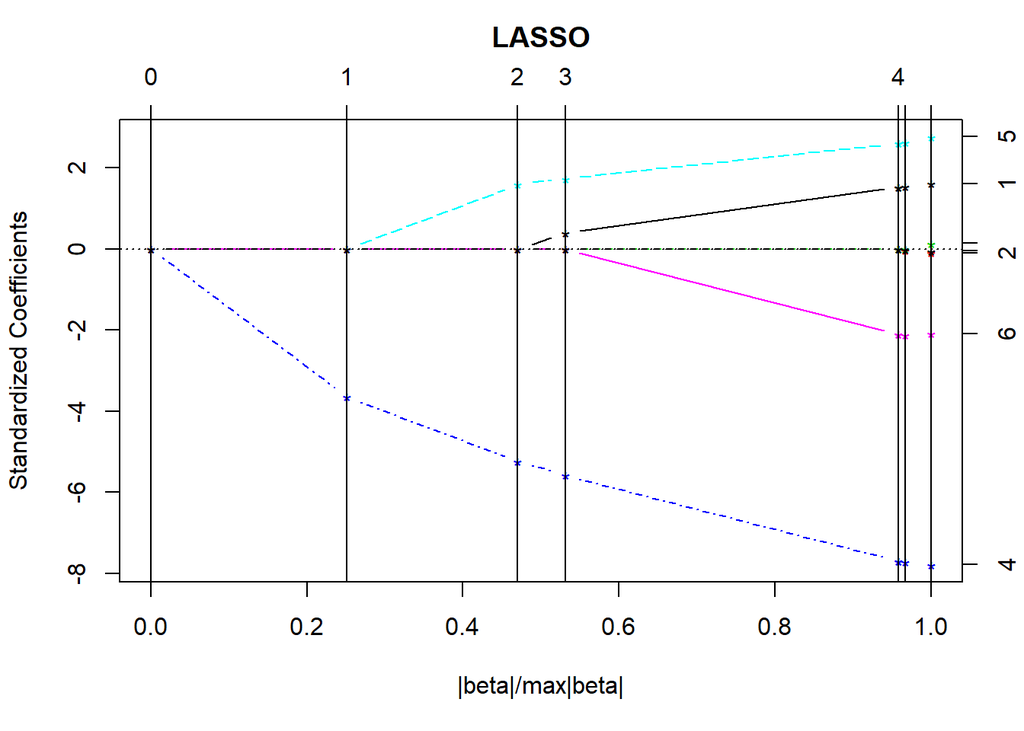

```r
data(state)
statedata <- data.frame(state.x77,row.names=state.abb)
lmod <- lars(as.matrix(statedata[,-4]),statedata$Life)
plot(lmod)
```

We can see the solution path for this model.

```r
set.seed(123)
cvlmod <- cv.lars(as.matrix(statedata[,-4]),statedata$Life)   # LASSO fitting with CV
```

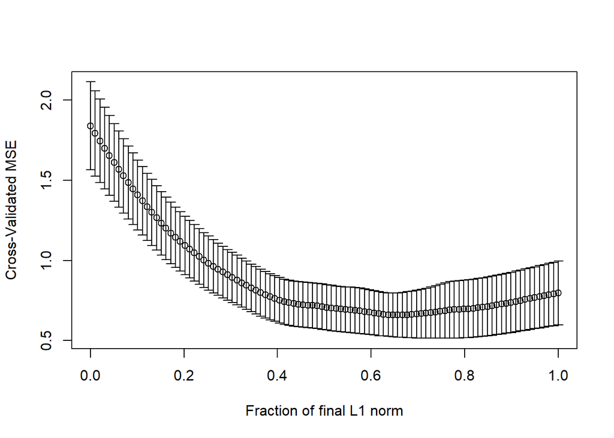

```r
cvlmod
```

```
## $index
##   [1] 0.00000000 0.01010101 0.02020202 0.03030303 0.04040404 0.05050505
##   [7] 0.06060606 0.07070707 0.08080808 0.09090909 0.10101010 0.11111111
##  [13] 0.12121212 0.13131313 0.14141414 0.15151515 0.16161616 0.17171717
##  [19] 0.18181818 0.19191919 0.20202020 0.21212121 0.22222222 0.23232323
##  [25] 0.24242424 0.25252525 0.26262626 0.27272727 0.28282828 0.29292929
##  [31] 0.30303030 0.31313131 0.32323232 0.33333333 0.34343434 0.35353535
##  [37] 0.36363636 0.37373737 0.38383838 0.39393939 0.40404040 0.41414141
##  [43] 0.42424242 0.43434343 0.44444444 0.45454545 0.46464646 0.47474747
##  [49] 0.48484848 0.49494949 0.50505051 0.51515152 0.52525253 0.53535354
##  [55] 0.54545455 0.55555556 0.56565657 0.57575758 0.58585859 0.59595960
##  [61] 0.60606061 0.61616162 0.62626263 0.63636364 0.64646465 0.65656566
##  [67] 0.66666667 0.67676768 0.68686869 0.69696970 0.70707071 0.71717172
##  [73] 0.72727273 0.73737374 0.74747475 0.75757576 0.76767677 0.77777778
##  [79] 0.78787879 0.79797980 0.80808081 0.81818182 0.82828283 0.83838384
```

[output cut: 40 more lines]

```r
cvlmod$index[which.min(cvlmod$cv)]                          # estimated lambda
```

[output not shown]

```r
predict(lmod,s=0.65657,type="coef",mode="fraction")$coef
```

```
##    Population        Income    Illiteracy        Murder       HS.Grad
##  2.345299e-05  0.000000e+00  0.000000e+00 -2.398794e-01  3.528887e-02
##         Frost          Area
## -1.694991e-03  0.000000e+00
```

```r
coef(lm(Life.Exp ~ Population+Murder+HS.Grad+Frost, statedata))
```

```
##   (Intercept)    Population        Murder       HS.Grad         Frost
##  7.102713e+01  5.013998e-05 -3.001488e-01  4.658225e-02 -5.943290e-03
```

Note here that `fraction` means $\sum_j|\hat\beta_j|/\sum_j|\hat\beta_{j0}|$ where $\hat\beta_{j0}$ comes from the standard linear model.

Lasso is most useful for problems with much larger numbers of variables such as the ongoing spectroscopy example of this chapter. We compute the lasso fit for the training data:

```r
trainy <- trainmeat$fat
trainx <- as.matrix(trainmeat[,-101])
lassomod <- lars(trainx,trainy)
set.seed(123)
cvout <- cv.lars(trainx,trainy)
```

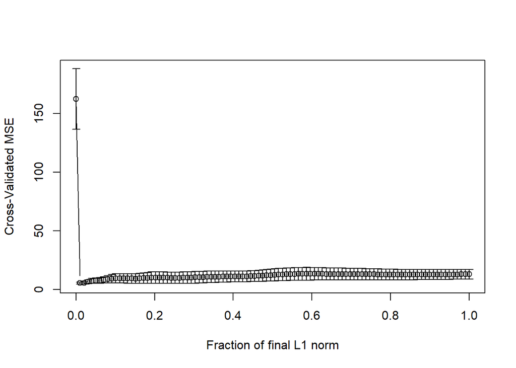

```r
cvout$index[which.min(cvout$cv)]
```

```
## [1] 0.01010101
```

```r
testx <- as.matrix(testmeat[,-101])
predlars <- predict(lassomod,testx,s=0.0101,mode="fraction")
rmse(testmeat$fat, predlars$fit)
```

```
## [1] 2.132269
```

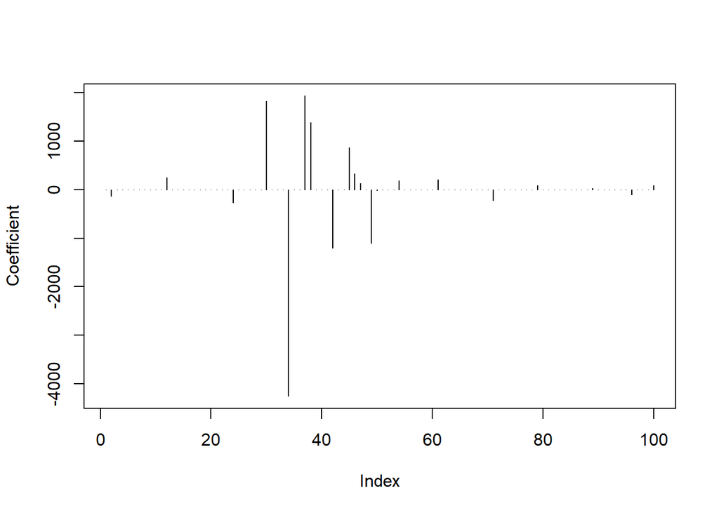

```r
predlars <- predict(lassomod, s=0.0101, type="coef", mode="fraction")
plot(predlars$coef,type="h",ylab="Coefficient")
```

```r
sum(predlars$coef != 0)
```

```
## [1] 20
```

The lasso is particularly useful when we believe the effects are sparse, i.e., that few of the predictors have an effect. For example, this arises in the analysis of gene expression data where we have good reason to believe that only a small number of genes have an influence on the quantity of interest.

# 3 Exercise

1. # 11.4 (a) (b) (e) + LASSO